```r
library("forecast")
```

```r
library("graphics")
library("TTR")
library("TSA")
```

### Data yang digunakan

Data bersumber dari kaggle yaitu data Daily Gold Price dari tahun 2014-2022. Data ini merupakan data harian . Selanjutnya untuk analisis dilakukan filterisasi pada tahun, dengan rentang tahun 2021-2022 dipilih untuk dilakukan analisis. Sehingga total data untuk analisis berjumlah 412 baris.

```r
library(rio)
library(readxl)
data <- import("https://raw.githubusercontent.com/AsfiahA/Tugas-mpdw/main/Tugas1/datampdw.csv")
head(data)
```

```
##         Date Price
## 1 2021-01-01 50081
## 2 2021-01-04 51349
## 3 2021-01-05 51456
## 4 2021-01-06 50545
## 5 2021-01-07 50918
## 6 2021-01-08 49035
```

```r
data.ts <- ts(data$Date)
data.ts <- ts(data$Price)
```

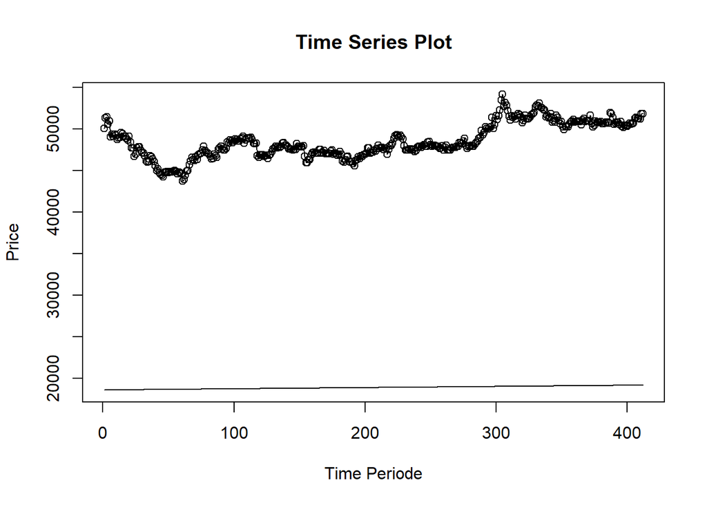

```r
ts.plot(data, xlab = "Time Periode", ylab = "Price", main = "Time Series Plot")
points(data.ts)
```

```r
train <- data[1:330,]
test <- data[331:412,]
train.ts <- ts(train$Price)
test.ts <- ts(test$Price)
```

### Eksplorasi Data

Eksplorasi data dilakukan pada keseluruhan data, data latih serta data uji menggunakan plot data deret waktu.

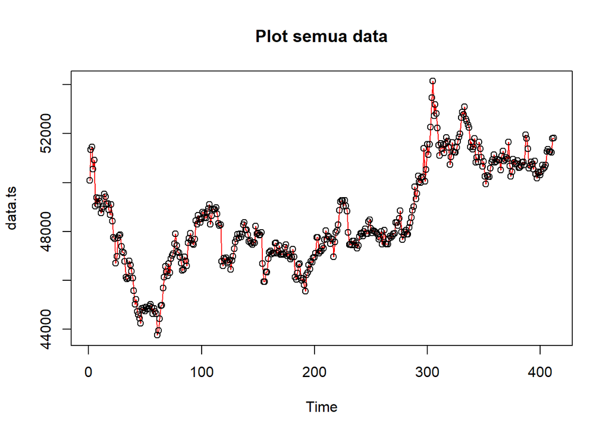

```r
#eksplorasi keseluruhan data
plot(data.ts, col="red",main="Plot semua data")
points(data.ts)
```

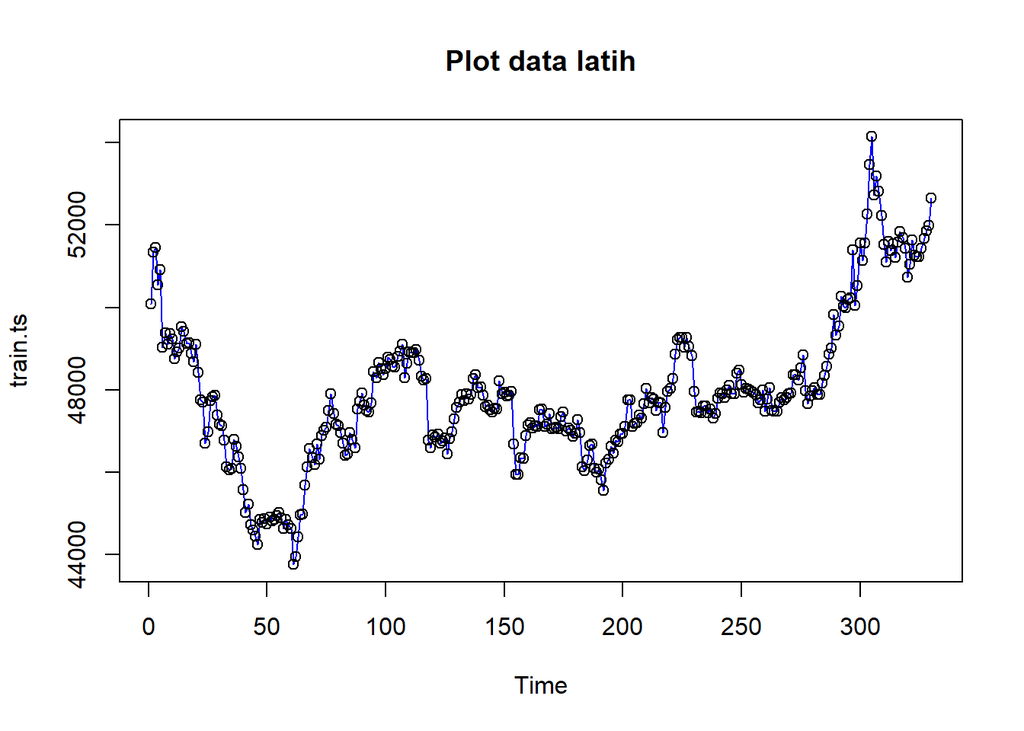

```r
#eksplorasi data latih
plot(train.ts, col="blue",main="Plot data latih")
points(train.ts)
```

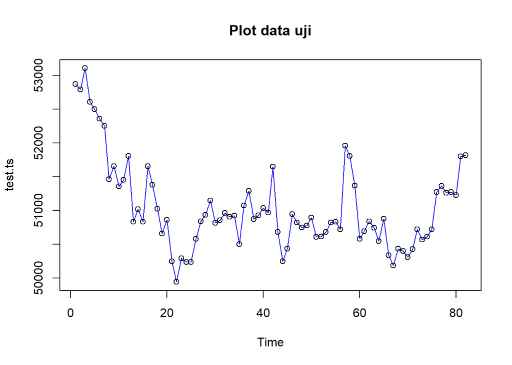

```r
#eksplorasi data uji
plot(test.ts, col="blue",main="Plot data uji")
points(test.ts)
```

Dapat terlihat pada data keseluruhan bahwa plot cenderung membentuk trend naik.

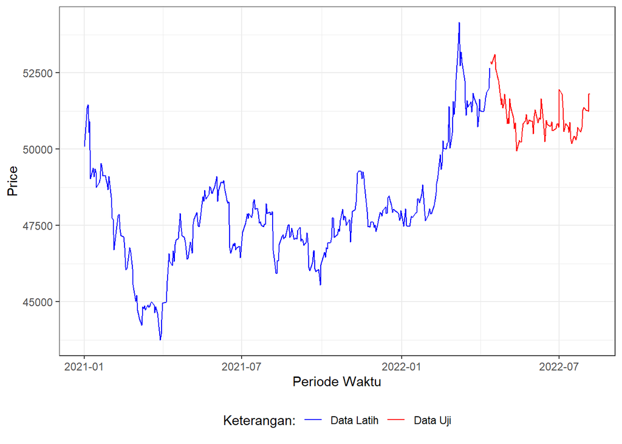

```r
#Eksplorasi dengan GGPLOT
library(ggplot2)
ggplot() +
  geom_line(data = train, aes(x = Date, y = Price, col = "Data Latih")) +
  geom_line(data = test, aes(x = Date, y = Price, col = "Data Uji")) +
  labs(x = "Periode Waktu", y = "Price", color = "Legend") +
  scale_colour_manual(name="Keterangan:", breaks = c("Data Latih", "Data Uji"),
                      values = c("blue", "red")) +
  theme_bw() + theme(legend.position = "bottom",
                     plot.caption = element_text(hjust=0.5, size=10))
```

### Pemulusan Karena data cenderung membentuk trend naik maka metode pemulusan yang akan dilakukan yaitu membandingkan antara Double Moving Average (DMA) dan Double Exponential Smoothing (DES).

### Double Moving Average (DMA)

Proses pemulusan dengan rata rata dalam metode ini dilakukan sebanyak 2 kali. Dengan m=4

```r
dma <- SMA(data.ts, n = 4)
At <- 2*data.ts - dma
Bt <- 2/(4-1)*(data.ts - dma)
data.dma<- At+Bt
data.ramal2<- c(NA, data.dma)

t = 1:24
f = c()

for (i in t) {
  f[i] = At[length(At)] + Bt[length(Bt)]*(i)
}

data.gab2 <- cbind(aktual = c(train.ts,rep(NA,24)), pemulusan1 = c(data.ts,rep(NA,24)),pemulusan2 = c(data.dma, rep(NA,24)),At = c(At, rep(NA,24)), Bt = c(Bt,rep(NA,24)),ramalan = c(data.ramal2, f[-1]))
data.gab2
```

```
##        aktual pemulusan1 pemulusan2       At           Bt  ramalan
##   [1,]  50081      50081         NA       NA           NA       NA
##   [2,]  51349      51349         NA       NA           NA       NA
##   [3,]  51456      51456         NA       NA           NA       NA
##   [4,]  50545      50545   50023.75 50232.25 -208.5000000       NA
##   [5,]  50918      50918   50669.67 50769.00  -99.3333333 50023.75
##   [6,]  49035      49035   46612.50 47581.50 -969.0000000 50669.67
##   [7,]  49386      49386   48411.00 48801.00 -390.0000000 46612.50
##   [8,]  49098      49098   48245.92 48586.75 -340.8333333 48411.00
##   [9,]  49354      49354   49580.25 49489.75   90.5000000 48245.92
##  [10,]  49238      49238   49186.33 49207.00  -20.6666667 49580.25
##  [11,]  48745      48745   48138.75 48381.25 -242.5000000 49186.33
##  [12,]  48918      48918   48675.08 48772.25  -97.1666667 48138.75
##  [13,]  49011      49011   49066.00 49044.00   22.0000000 48675.08
##  [14,]  49528      49528   50323.83 50005.50  318.3333333 49066.00
```

[output cut: 422 more lines]

Hasil pemulusan menggunakan metode DMA divisualisasikan sebagai berikut

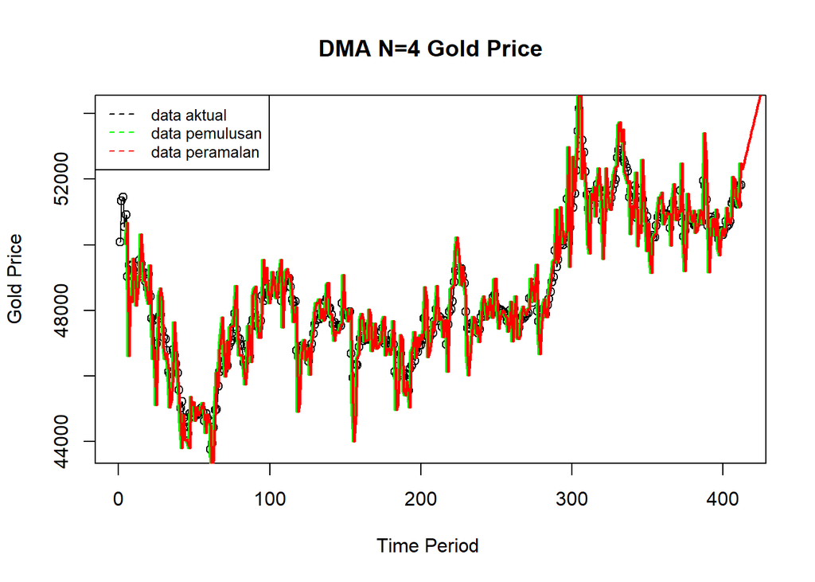

```r
ts.plot(data.ts, xlab="Time Period ", ylab="Gold Price", main= "DMA N=4 Gold Price")
points(data.ts)
lines(data.gab2[,3],col="green",lwd=2)
lines(data.gab2[,6],col="red",lwd=2)
legend("topleft",c("data aktual","data pemulusan","data peramalan"), lty=8, col=c("black","green","red"), cex=0.8)
```

Selanjutnya perhitungan akurasi dilakukan baik pada data latih maupun data uji. Perhitungan akurasi dilakukan dengan ukuran akurasi SSE, MSE dan MAPE.

```r
#Menghitung nilai keakuratan data latih
error_train.dma = train.ts-data.ramal2[1:length(train.ts)]
SSE_train.dma = sum(error_train.dma[20:length(train.ts)]^2)
MSE_train.dma = mean(error_train.dma[20:length(train.ts)]^2)
MAPE_train.dma = mean(abs((error_train.dma[20:length(train.ts)]/train.ts[20:length(train.ts)])*100))

akurasi_train.dma <- matrix(c(SSE_train.dma, MSE_train.dma, MAPE_train.dma))
row.names(akurasi_train.dma)<- c("SSE", "MSE", "MAPE")
colnames(akurasi_train.dma) <- c("Akurasi m = 4 ")
akurasi_train.dma
```

```
##      Akurasi m = 4
## SSE    1.536752e+08
## MSE    4.941326e+05
## MAPE   1.080836e+00
```

```r
#Menghitung nilai keakuratan data uji
error_test.dma = test.ts-data.gab2[331:354,6]
```

```r
SSE_test.dma = sum(error_test.dma^2)
MSE_test.dma = mean(error_test.dma^2)
MAPE_test.dma = mean(abs((error_test.dma/test.ts*100)))

akurasi_test.dma <- matrix(c(SSE_test.dma, MSE_test.dma, MAPE_test.dma))
row.names(akurasi_test.dma)<- c("SSE", "MSE", "MAPE")
colnames(akurasi_test.dma) <- c("Akurasi m = 4")
akurasi_test.dma
```

```
##      Akurasi m = 4
## SSE   1.530124e+08
## MSE   1.866005e+06
## MAPE  2.096172e+00
```

### DES

Untuk mendapatkan nilai parameter optimum dari DES, argumen `alpha` dan `beta` dapat dibuat `NULL` seperti berikut.

```r
#Lamda dan gamma optimum
des.opt<- HoltWinters(train.ts, gamma = FALSE)
des.opt
```

```
## Holt-Winters exponential smoothing with trend and without seasonal component.
##
## Call:
## HoltWinters(x = train.ts, gamma = FALSE)
##
## Smoothing parameters:
##  alpha: 1
##  beta : 0.1763385
##  gamma: FALSE
##
## Coefficients:
##         [,1]
## a 52656.0000
## b   188.6348
```

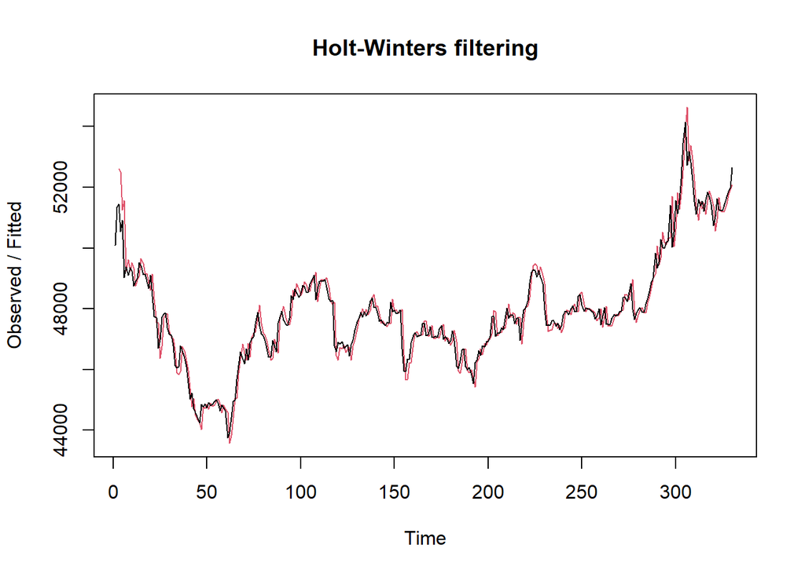

```r
plot(des.opt)
```

```r
#ramalan
ramalandesopt<- forecast(des.opt, h=84)
ramalandesopt
```

```
##     Point Forecast    Lo 80     Hi 80        Lo 95     Hi 95
## 331       52844.63 52282.72  53406.55 51985.256844  53704.01
## 332       53033.27 52165.70  53900.84 51706.435616  54360.10
## 333       53221.90 52068.47  54375.34 51457.873941  54985.94
## 334       53410.54 51972.27  54848.81 51210.901686  55610.18
## 335       53599.17 51870.91  55327.43 50956.027537  56242.32
## 336       53787.81 51761.76  55813.86 50689.230552  56886.39
## 337       53976.44 51643.58  56309.31 50408.639430  57544.25
## 338       54165.08 51515.81  56814.34 50113.378616  58216.78
## 339       54353.71 51378.22  57329.21 49803.081331  58904.35
## 340       54542.35 51230.72  57853.97 49477.657093  59607.04
## 341       54730.98 51073.39  58388.58 49137.170908  60324.80
## 342       54919.62 50906.30  58932.94 48781.776570  61057.46
## 343       55108.25 50729.60  59486.91 48411.678152  61804.83
## 344       55296.89 50543.43  60050.34 48027.107042  62566.67
```

[output cut: 70 more lines]

Didapatkan nilai parameter optimum dari DES yaitu alpha=1 dan beta=0.1763385

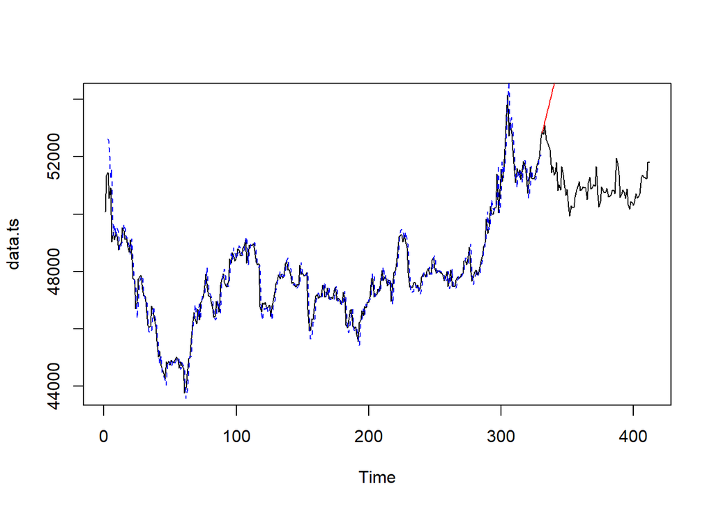

```r
#Membandingkan plot data latih dan data uji
plot(data.ts)
lines(des.opt$fitted[,1], lty=2, col="blue")
lines(ramalandesopt$mean, col="red")
```

Selanjutnya akan dilakukan perhitungan akurasi pada data latih maupun data uji dengan ukuran akurasi SSE, MSE dan MAPE.

#### Akurasi Data Latih

```r
#Akurasi Data Training
ssedes.train<-des.opt$SSE
msedes.train<-ssedes.train/length(train.ts)
sisaandes<-ramalandesopt$residuals
head(sisaandes)
```

```
## Time Series:
## Start = 1
## End = 6
## Frequency = 1
## [1]        NA        NA -1161.000 -1974.271  -342.131 -2537.800
```

```r
mapedes.train <- sum(abs(sisaandes[3:length(train.ts)]/train.ts[3:length(train.ts)])
                      *100)/length(train.ts)

akurasides.opt <- matrix(c(ssedes.train,msedes.train,mapedes.train))
row.names(akurasides.opt)<- c("SSE", "MSE", "MAPE")
colnames(akurasides.opt) <- c("Akurasi (optimum) lambda=1 dan gamma=0.176")
akurasides.opt
```

```
##      Akurasi (optimum) lambda=1 dan gamma=0.176
## SSE                                6.298083e+07
## MSE                                1.908510e+05
## MAPE                               6.279135e-01
```

Hasil akurasi dari data latih dengan lamda=1 dan gamma=0.176 memiliki hasil yang optimal dan dapat dikategorikan peramalan sangat baik berdasarkan nilai MAPE-nya yang kurang dari 10%.

#### Akurasi Data Uji

```r
#Akurasi Data Testing
selisihdesopt<-ramalandesopt$mean-test$Price
selisihdesopt
```

```
## Time Series:
## Start = 331
## End = 414
## Frequency = 1
##  [1]   -26.36517   240.26966   117.90448   807.53931  1100.17414  1431.80897
##  [7]  1726.44379  2703.07862  2698.71345  3185.34828  3280.98311  3110.61793
## [13]  4277.25276  4274.88759  4649.52242  4021.15724  4481.79207  5025.42690
## [19]  5578.06173  5566.69656  6368.33138  6861.96621  6703.60104  6946.23587
## [25]  7136.87069  6981.50552  6907.14035  7003.77518  6980.41001  7500.04483
## [31]  7645.67966  7731.31449  7972.94932  8145.58414  8754.21897  8368.85380
## [37]  8348.48863  8953.12346  9083.75828  9165.39311  9419.02794  8928.66277
## [43] 10085.29759 10704.93242 10711.56725 10388.20208 10697.83691 10962.47173
## [49] 11124.10656 11189.74139 11668.37622 11851.01104 11972.64587 12018.28070
## [55] 12194.91553 12500.55036 11447.18518 11788.82001 12415.45484 13393.08967
## [61] 13471.72449 13511.35932 13794.99415 14181.62898 14037.26381 14765.89863
## [67] 15109.53346 15049.16829 15268.80312 15551.43794 15622.07277 15517.70760
## [73] 15859.34243 16002.97726 16081.61208 15718.24691 15815.88174 16109.51657
## [79] 16284.15139 16521.78622 16133.42105 16304.05588 15441.69071 15708.32553
```

```r
SSEtestingdesopt<-sum(selisihdesopt^2)
MSEtestingdesopt<-SSEtestingdesopt/length(test$Price)
MAPEtestingdesopt<-sum(abs(selisihdesopt/test$Price)*100)/length(test$Price)
akurasitestingdes <-
  matrix(c(SSEtestingdesopt,MSEtestingdesopt,MAPEtestingdesopt),
         nrow=3,ncol=1)
row.names(akurasitestingdes)<- c("SSE", "MSE", "MAPE")
colnames(akurasitestingdes) <- c("des opt")
akurasitestingdes
```

```
##           des opt
## SSE  9.648808e+09
## MSE  1.176684e+08
## MAPE 1.927339e+01
```

Hasil akurasi dari data uji dapat dikategorikan peramalan yang baik berdasarkan MAPE-nya yang bernilai 19.27.

# Kesimpulan

```r
# Perbandigan Data Latih
perbandingan_data_latih <-
  matrix(c(SSE_train.dma, MSE_train.dma, MAPE_train.dma,ssedes.train,msedes.train,mapedes.train),
         nrow=3,ncol=2)
row.names(perbandingan_data_latih)<- c("SSE", "MSE", "MAPE")
colnames(perbandingan_data_latih) <- c("DMA", "DES")
perbandingan_data_latih
```

```
##               DMA          DES
## SSE  1.536752e+08 6.298083e+07
## MSE  4.941326e+05 1.908510e+05
## MAPE 1.080836e+00 6.279135e-01
```

```r
# Perbandingan Data Uji
perbandingan_data_uji <-
  matrix(c(SSE_test.dma, MSE_test.dma, MAPE_test.dma,SSEtestingdesopt,MSEtestingdesopt,MAPEtestingdesopt),
         nrow=3,ncol=2)
row.names(perbandingan_data_uji)<- c("SSE", "MSE", "MAPE")
colnames(perbandingan_data_uji) <- c("DMA", "DES")
perbandingan_data_uji
```

```
##               DMA          DES
## SSE  1.530124e+08 9.648808e+09
## MSE  1.866005e+06 1.176684e+08
## MAPE 2.096172e+00 1.927339e+01
```

Dapat terlihat bahwa pada data latih DES nilai akurasi (MAPE) lebih baik daripada data latih DMA, dimana nilai MAPE < 10%, sehingga dapat dikatakan peramalan sangat baik.